# Final Assignment

Nile Ansotegi, Lúa Arconada and Alejandro Macías

2024-05-14

# 1 Assignment 1

```r
library(igraph)
library(chorddiag)
set.seed(1234)
```

We present a social network dataset based on interactions between members of the 117th United States Congress between Feb. 9, 2022, and June 9, 2022. The dataset takes the form of a directed, weighted network in which the edge weights are empirically obtained “probabilities of influence” between all pairs of Congresspeople.

We have 475 vertices and 13289 edges.

Twitter’s application programming interface (API) V2 was used to determine the number of times each member of Congress retweeted, quote tweeted, replied to, or mentioned other Congressional members, and the probability of influence was found by normalizing the summed influence by the number of tweets issued by each Congressperson. This network may be of particular interest to the study of information diffusion within social networks.

```r
data = read.table("congress.edgelist", sep="", header=F,
                  col.names=c("V1", "V2", "delete", "weight"))
data = data[,-3]
data$weight = gsub("}", '', data$weight)
data$weight = as.numeric(data$weight)
```

```r
data.attr = read.csv("gender-party.csv",sep=";", na.strings="")
data.attr$Gender = factor(data.attr$Gender)
data.attr$Party = factor(data.attr$Party)
```

```r
g = igraph::graph_from_data_frame(data)
# set vertex attributes
g = set_vertex_attr(g, "name", value=data.attr$Name)
g = set_vertex_attr(g, "gender", value=data.attr$Gender)
g = set_vertex_attr(g, "affiliation", value=data.attr$Party)
```

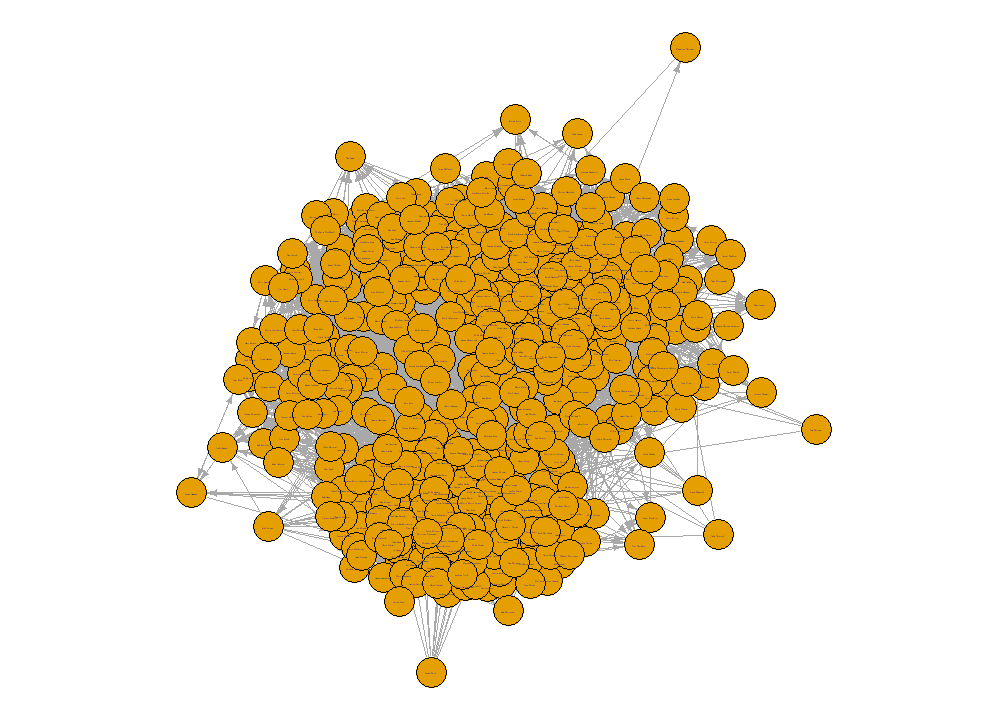

```r
par(mar=c(0,0,0,0)+.3)
plot(g, vertex.size=10, vertex.label.cex=0.15, edge.labels=data$weight, edge.arrow.size=0.5)
```

The graph presents several challenges that impact our ability to draw clear conclusions. While there are likely alternative visualization methods that could offer better clarity, we have not yet explored these approaches in class.

Firstly, the structure of the graph makes it difficult to discern communities due to overlapping edges and vertices. Observing the network, we could say that there are two main communities. These communities could correspond to people from the same political party, influencing each other more often whilst being in the same political party.

Additionally, the graph is directed and weighted, suggesting that certain nodes exert more influence than others. Notably, the user 227 may be an influencer, since many arrows go from it to other users.

Furthermore, the graph is connected since, despite there probably being two communities, they are not isolated due to the frequency of arguments between members of opposing political parties. The exact nature of this connectivity remains partially unknown. We suspect that if certain nodes were to be isolated or clustered together, it would be noticed in the plot. Since we cannot be sure as this is simply a visual study, further analysis is needed to confirm these patterns.

Lastly, this network contains both single and double edges, as two people can interact mutually on Twitter, such as in the case of the influence relation between nodes 285 and 390. One interesting feature of such double edges is that the weight is not necessarily symmetric, that is, the influence might be higher in direction than in the other, due to the fact that one user might retweet or quote-retweet a different user more than they are retweeted or quote-retweeted by them, which could be exemplified by a member of lower rank retweeting the leader of their political party.

# 2 Assignment 2

## 2.1 Main characteristics of the network

We can take a quick look at the `igraph` object, as well as visualize the graph with a basic plot:

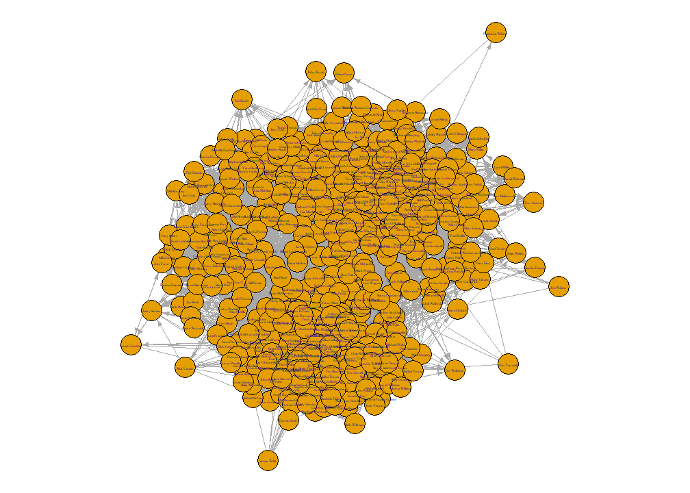

```r
par(mar=c(0,0,0,0)+.3)
plot(g, vertex.size=10, vertex.label.cex=0.3, edge.labels=data$weight, edge.arrow.size=0.5)
```

```r
summary(g)
```

```
## IGRAPH b93968b DNW- 475 13289 --
## + attr: name (v/c), gender (v/x), affiliation (v/x), weight (e/n)
```

The graph’s vertices are labeled with the name of the Congressperson that they represent. Besides said names, each vertex contains two attributes, representing person’s gender and their political affiliation. The graph’s edges contain the `weight` attribute, which represents the strength of the influence exerted by one Congressperson on another.

we can modify the plot in order to better visualize the different attributes, starting with `gender`.

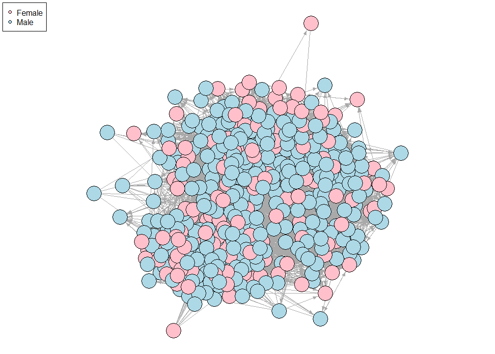

```r
par(mar=c(0,0,0,0)+.3)
# Create a vector of colors based on gender
gender_colors <- ifelse(V(g)$gender == "Male", "lightblue", "pink")

plot(g, vertex.color=gender_colors,
     vertex.label=NA,
     vertex.size=10,
     vertex.label.cex=0.25,
     edge.labels=data$weight,
     edge.arrow.size=0.5)

legend('topleft',
       legend=levels(data.attr$Gender),
       pch=21,
       pt.bg=c( "pink", "lightblue")
       )
```

The same process can be repeated for `affiliation`.

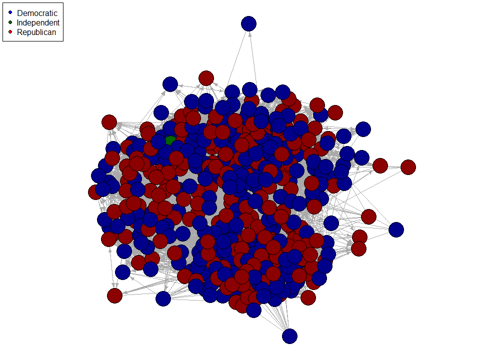

```r
par(mar=c(0,0,0,0)+.3)
# Create a vector of colors based on gender
party_colors <- ifelse(V(g)$affiliation == "Republican","darkred",
                       ifelse(V(g)$affiliation=="Democratic","darkblue","darkgreen"))

plot(g,
     vertex.color = party_colors,
     vertex.label=NA,
     vertex.size=10,
     vertex.label.cex=0.25,
     edge.labels=data$weight,
     edge.arrow.size=0.5)

legend('topleft',
       legend=levels(data.attr$Party),
       pch=21,
       pt.bg=c("blue", "darkgreen", "red")
       )
```

Due to the definition itself of the network, it is expected to be directed and to lack both multiple edges and loops. Nonetheless, this can be checked computationally.

Firstly, we simply check if it is directed.

```r
is_directed(g)
```

```
## [1] TRUE
```

Secondly, the existence (or lack thereof) of loops can be verified:

```r
any_loop(g)
```

```
## [1] FALSE
```

The final verification consists of checking whether the graph contains multiple edges. In a directed graph, this is defined as having several arrows pointing in the same direction, and so edges between the same vertices but in opposite directions do not count as such.

```r
any_multiple(g)
```

```
## [1] FALSE
```

Since the graph does not contain loops nor multiple edges, we are dealing with a directed simple graph.

As far as subnetworks are concerned, it might be interesting to study more in depth those induced by the different vertex attributes. We can start by visualizing the three distinct subnetworks induced by the political affiliation:

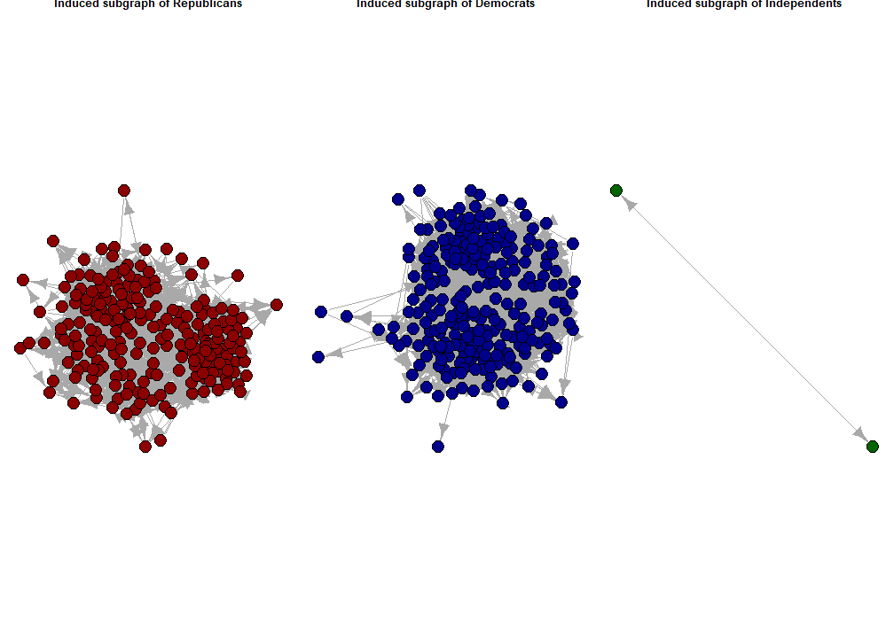

```r
republicans <- which(V(g)$affiliation=="Republican")
g.rep <- induced_subgraph(g,republicans)

democrats <- which(V(g)$affiliation=="Democratic")
g.dem <- induced_subgraph(g,democrats)

independents <- which(V(g)$affiliation=="Independent")
g.ind <- induced_subgraph(g,independents)

par(mar=c(0,0,0,0)+.3, mfrow=c(1,3))

plot.igraph(g.rep,
            vertex.label=NA,
            vertex.size=10,
            vertex.label.cex=0.25,
            main="Induced subgraph of Republicans",
            vertex.color="darkred")

plot.igraph(g.dem,
            vertex.label=NA,
            vertex.size=10,
            vertex.label.cex=0.25,
            main="Induced subgraph of Democrats",
            vertex.color="darkblue")

plot.igraph(g.ind,
            vertex.label=NA,
            vertex.size=10,
            vertex.label.cex=0.25,
            main="Induced subgraph of Independents",
            vertex.color="darkgreen")
```

Perhaps, it could also be interesting to study the subnetworks induced by the gender of the Congresspeople, which take the following aspects:

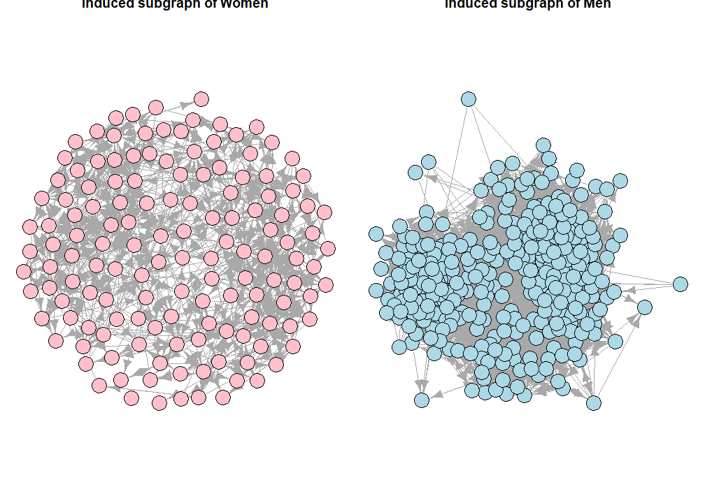

```r
women <- which(V(g)$gender=="Female")
g.w <- induced_subgraph(g,women)

men <- which(V(g)$gender=="Male")
g.m <- induced_subgraph(g,men)

par(mar=c(0,0,0,0)+.3, mfrow=c(1,2))

plot.igraph(g.w,
            vertex.label=NA,
            vertex.size=10,
            vertex.label.cex=0.25,
            main="Induced subgraph of Women",
            vertex.color="pink")

plot.igraph(g.m,
            vertex.label=NA,
            vertex.size=10,
            vertex.label.cex=0.25,
            main="Induced subgraph of Men",
            vertex.color="lightblue")
```

## 2.2 Order, size and subnetworks of interest

The order and size of the main graph are:

```r
vcount(g)  # Number of vertices (order)
```

```
## [1] 475
```

```r
ecount(g)  # Number of edges (size)
```

```
## [1] 13289
```

We can also compute these values for the distinct subnetworks mentioned in the previous section.

Starting with the subnetworks induced by gender:

```r
print("Men's subnetwork")
```

```
## [1] "Men's subnetwork"
```

```r
print(paste("Order:",vcount(g.m)))
```

```
## [1] "Order: 335"
```

```r
print(paste("Size:",ecount(g.m)))
```

```
## [1] "Size: 7141"
```

```r
print("")
```

```
## [1] ""
```

```r
print("Women's subnetwork")
```

```
## [1] "Women's subnetwork"
```

```r
print(paste("Order:",vcount(g.w)))
```

```
## [1] "Order: 140"
```

```r
print(paste("Size:",ecount(g.w)))
```

```
## [1] "Size: 881"
```

The female politician’s subnetwork contains only about 30% of the total number of nodes, indicating a notable gender inequality in the representation at the US Congress level. Furthermore, These Congresswomen interact with (and so are less influenced by, according to the metric in the study) one another much less than men do. It is also interesting to note that this indicates that there must be more than 5000 edges joining the two subnetworks, meaning that the influence an individual exerts, as well as the influences they receive, are not contained to those of their own gender.

Now, moving onto the subnetworks induced by political affiliation, ignoring the subnetwork of independent politicians due to its simplicity:

```r
print("Republican's subnetwork")
```

```
## [1] "Republican's subnetwork"
```

```r
print(paste("Order:",vcount(g.rep)))
```

```
## [1] "Order: 222"
```

```r
print(paste("Size:",ecount(g.rep)))
```

```
## [1] "Size: 3028"
```

```r
print("")
```

```
## [1] ""
```

```r
print("Democrat's subnetwork")
```

```
## [1] "Democrat's subnetwork"
```

```r
print(paste("Order:",vcount(g.dem)))
```

```
## [1] "Order: 251"
```

```r
print(paste("Size:",ecount(g.dem)))
```

```
## [1] "Size: 3455"
```

As opposed to the previous case, these subnetworks seems much more balanced, having quite similar values for both order and size. In fact, the most interesting feature of these subnetworks is not found in what they contain, but rather in what the lack: the total edges contained in both of them account only for slightly less than half of the number of edges of the main network. This indicates that there is a very high level of interaction, and so of influence, between members of opposing political parties in the US Congress.

## 2.3 Degree distribution(s)

Now, the degree distribution of the graph and some subnetworks of interest will be studied.

Starting with the degree distribution without taking into account the weights, we can begin by checking that the sum of all the vertices’ degrees is equal to twice the size of the graph:

```r
sum(degree(g)) == 2*gsize(g) #2*size
```

```
## [1] TRUE
```

Now, we can compute and visualize the total degree distribution of the network:

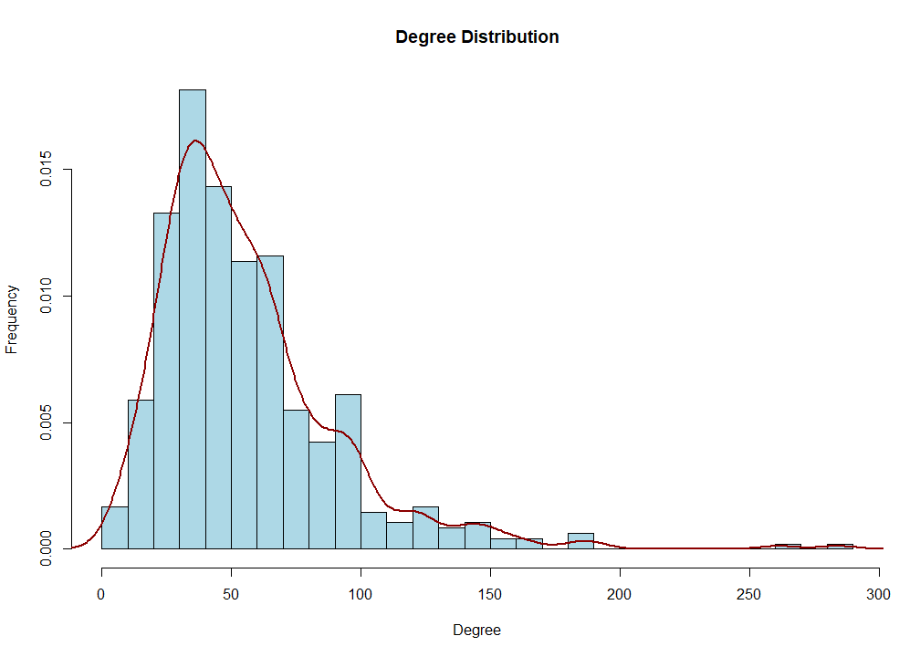

```r
# Calculate total degrees (sum of in-degree and out-degree for undirected graphs)
degrees <- degree(g, mode = "total")

# Plot degree distribution
hist(degrees, breaks = 30, main = "Degree Distribution",
     xlab = "Degree", ylab = "Frequency", freq=F, col="lightblue")
lines(density(degrees),col="darkred", lwd=2.5)
```

We can now compute some important statistics of the total degree distribution.

```r
min(degrees)
```

```
## [1] 2
```

```r
mean(degrees)
```

```
## [1] 55.95368
```

```r
median(degrees)
```

```
## [1] 48
```

```r
max(degrees)
```

```
## [1] 284
```

We can see both in the histogram and in the statistics that the distribution presents a strong right-skewness, with very few (although present) individuals influencing numerous Congresspeople and a peak at around 40.

Now, we can compute the degree distribution taking into account the weights. In this case, a large weight implies a very close relationship between two members of the network, which is exactly what interests us.

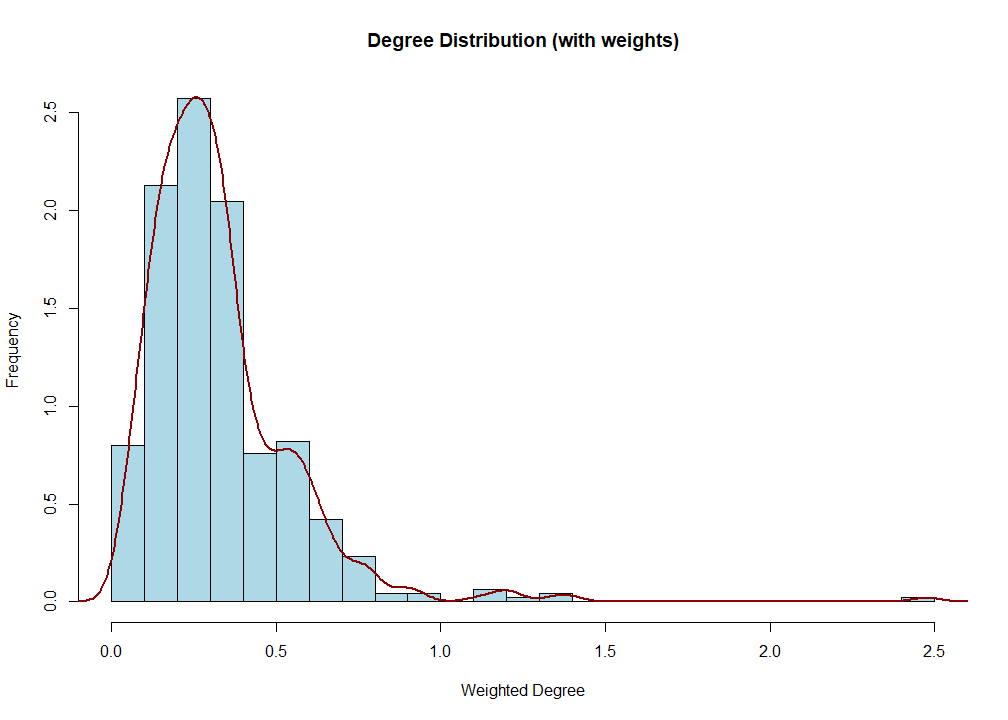

```r
# Compute weighted degree manually by summing edge weights
weighted_degree <- function(graph) {
  degree_vector <- degree(graph, mode = "total", loops = FALSE)
  weighted_degree_vector <- sapply(V(graph), function(v) sum(E(graph)[inc(v)]$weight))
  return(weighted_degree_vector)
}

# Calculate weighted degree distribution
weighted_degree_distribution <- weighted_degree(g)

# Plot weighted degree distribution
hist(weighted_degree_distribution, breaks = 20, main = "Degree Distribution (with weights)",
     xlab = "Weighted Degree", ylab = "Frequency", freq=F, col="lightblue")
lines(density(weighted_degree_distribution), lwd=2, col="darkred")
```

```r
min(strength(g))
```

```
## [1] 0.02264151
```

```r
median(strength(g))
```

```
## [1] 0.2810066
```

```r
mean(strength(g))
```

```
## [1] 0.3251765
```

```r
max(strength(g))
```

```
## [1] 2.4755
```

Once again, the distribution is very right-skewed, with very few extremely highly influential individuals.

So far, only the total degree has been considered. However, since we are dealing with a directed network, the in and out degrees can also be considered separately.

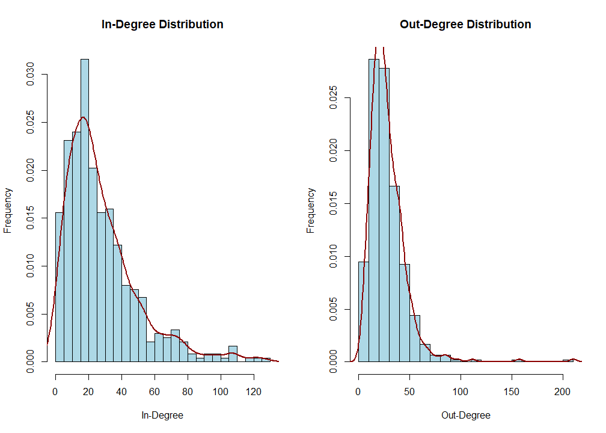

```r
in_degree_distribution <- degree(g, mode = "in", loops = FALSE)
out_degree_distribution <- degree(g, mode = "out", loops = FALSE)

par(mfrow=c(1,2))
# Plot in-degree distribution
hist(in_degree_distribution, breaks = 20, main = "In-Degree Distribution",
       xlab = "In-Degree", ylab = "Frequency", col="lightblue", freq=F)
lines(density(in_degree_distribution), lwd=2.5, col="darkred")

# Plot out-degree distribution
hist(out_degree_distribution, breaks = 20, main = "Out-Degree Distribution",
     xlab = "Out-Degree", ylab = "Frequency", col="lightblue", freq=F)
lines(density(out_degree_distribution), lwd=2.5, col="darkred")
```

## 2.4 Weak and strong components

A component of a graph is a subset of vertices and edges where every vertex is reachable from every other vertex within that subset, and no additional edges can be added without breaking this property of maximal connectivity. In a connected graph, there is only one component, encompassing all vertices, while in graphs with multiple components, each component represents a separate, maximally connected subgraph.

We check whether the network is connected both strongly and weakly.

```r
is_connected(g,mode="strong")
```

```
## [1] FALSE
```

```r
is_connected(g,mode="weak")
```

```
## [1] TRUE
```

It is only connected weakly. Then, the number of components is going to be 1 for the weakly connected network. For the strongly connected network, the number of components must be $>1$.

```r
length(components(g,mode="strong")$csize)
```

```
## [1] 7
```

```r
length(components(g,mode="weak")$csize)
```

```
## [1] 1
```

Indeed, we have seven components for the strongly connected network and one for the weak one.

```r
comp <- components(g, mode = "strong")
comp$csize
```

```
## [1]   1   1   1   1   1   1 469
```

Note that all the components except the last one have size 1. This means that we have 6 members that are not strongly connected to any other vertex, resulting in isolated vertices. After inspecting these 6 members, we don’t see any particular common caharcteristic among them.

The strongly connected subgraph of our graph is plotted below. Note that this is going to look like the graph but with 6 less vertices.

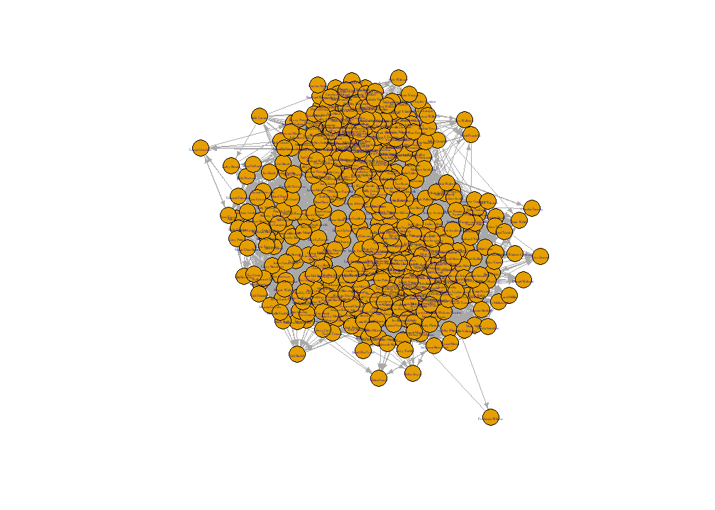

```r
subgraph_vertices <- V(g)[comp$membership == 7]
subgraph <- induced_subgraph(g, subgraph_vertices)
plot(subgraph,vertex.size=10, vertex.label.cex=0.3, edge.labels=data$weight, edge.arrow.size=0.5)
```

## 2.5 Diameter of the network

The diameter represents the maximum geodesic distance in the network, which is the shortest path length between two vertices. It’s a critical metric for understanding the overall connectivity and reachability within the network, often used to assess the efficiency of communication or transportation systems modeled by graphs.

Furthermore, the weighted geodesic distance can be defined as the path with the minimum sum of edge weights. It is also possible to compute the weighted diameter, defined the same way as the diameter but with weighted geodesic distnace instead.

We first compute the diameter without taking into account the weights. For that we create another network where the weights are the same for all edges.

```r
g_unweight<-g

E(g_unweight)$weight <- 1

get_diameter(g_unweight, directed = TRUE)
```

```
## + 7/475 vertices, named, from b93968b:
## [1] Chris Van Hollen         John Hoeven              Mike Gallagher
## [4] Mariannette Miller-Meeks Grace Meng               John Sarbanes
## [7] Frederica Wilson
```

```r
diameter(g_unweight, directed = TRUE)
```

```
## [1] 6
```

```r
get_diameter(g_unweight, directed = FALSE)
```

```
## + 5/475 vertices, named, from b93968b:
## [1] Joni Ernst       Rand Paul        Steve Cohen      Frank Lucas
## [5] Frederica Wilson
```

```r
diameter(g_unweight, directed = FALSE)
```

```
## [1] 4
```

Observe that the diameter is smaller for the undirected network. This makes sensedue to the lack to direction of the edges.

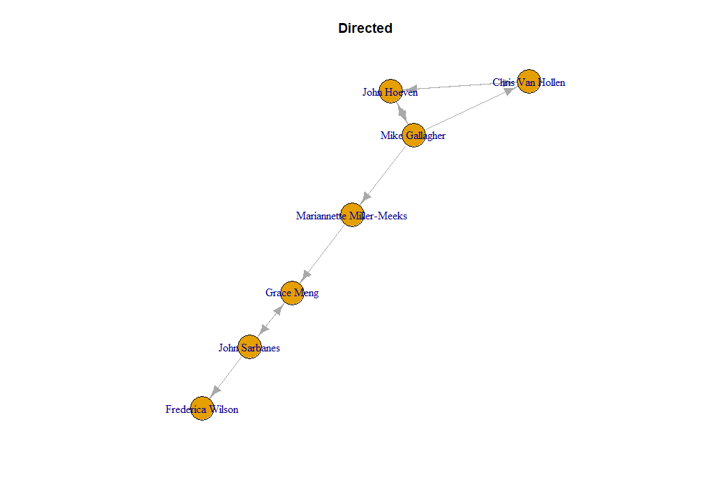

```r
names<-get_diameter(g_unweight,directed=TRUE)
vertex_names <- list()

for (i in 1:length(names)) {
  vertex_names[[i]] <- names[[i]]$name
}

vertex_indices <- V(g_unweight)$name %in% vertex_names

subgraph <- induced_subgraph(g_unweight, vertex_indices)

plot(subgraph,main="Directed")
```

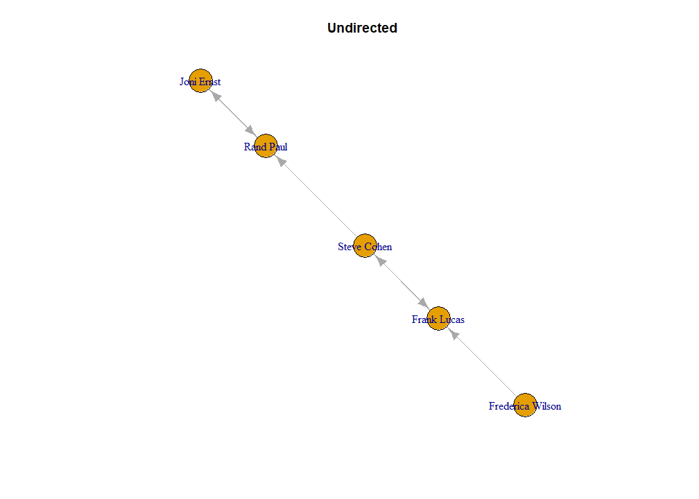

```r
names<-get_diameter(g_unweight,directed=FALSE)
vertex_names <- list()

for (i in 1:length(names)) {
  vertex_names[[i]] <- names[[i]]$name
}

vertex_indices <- V(g_unweight)$name %in% vertex_names

subgraph <- induced_subgraph(g_unweight, vertex_indices)

plot(subgraph, main="Undirected")
```

However, for our network, it is more interesting to obtain the weighted diameter.

We calculate and analyze the diameter of the network considering both directed and undirected networks.

```r
get_diameter(g,directed=TRUE)
```

```
## + 5/475 vertices, named, from b93968b:
## [1] Gregorio Kilili Camacho Sablan Grace Napolitano
## [3] David Carter                   John Sarbanes
## [5] Frederica Wilson
```

These are the names of the vertices that give the shortest path in the directed network, with Gregorio Kilili Camacho being the first vertex and Frederica Wilson being the fifth.

```r
diameter(g,directed=TRUE)
```

```
## [1] 0.03076809
```

```r
farthest_vertices(g,directed=TRUE)
```

```
## $vertices
## + 2/475 vertices, named, from b93968b:
## [1] Gregorio Kilili Camacho Sablan Frederica Wilson
##
## $distance
## [1] 0.03076809
```

We identify the names of the pair of vertices that are the endpoints of the longest shortest path in the directed network.

```r
V(g)$affiliation[get_diameter(g,directed=TRUE)]
```

```
## [1] Democratic Democratic Republican Democratic Democratic
## Levels: Democratic Independent Republican
```

```r
V(g)$gender[get_diameter(g,directed=TRUE)]
```

```
## [1] Male   Female Male   Male   Female
## Levels: Female Male
```

We see that they are no necessarily from the same political party nor the same gender.

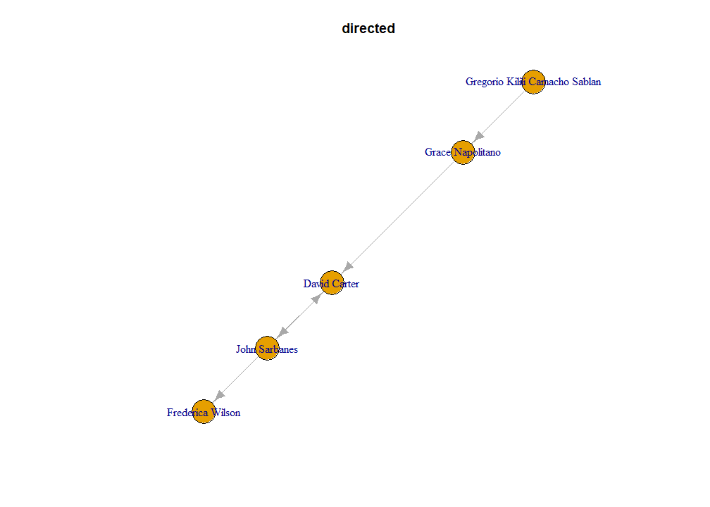

```r
names<-get_diameter(g,directed=TRUE)
vertex_names <- list()

for (i in 1:length(names)) {
  vertex_names[[i]] <- names[[i]]$name
}

vertex_indices <- V(g)$name %in% vertex_names

subgraph <- induced_subgraph(g, vertex_indices)

plot(subgraph,main="directed")
```

See that the path is not the same when we are working with the weighted geodesic distance. Now, we do the same for an undirected network.

```r
get_diameter(g,directed=FALSE)
```

```
## + 5/475 vertices, named, from b93968b:
## [1] Frederica Wilson Frank Lucas      Bernie Sanders   Louie Gohmert
## [5] Lee Zeldin
```

```r
diameter(g,directed=FALSE)
```

```
## [1] 0.02054742
```

```r
farthest_vertices(g,directed=FALSE)
```

```
## $vertices
## + 2/475 vertices, named, from b93968b:
## [1] Frederica Wilson Lee Zeldin
##
## $distance
## [1] 0.02054742
```

```r
V(g)$affiliation[get_diameter(g,directed=FALSE)]
```

```
## [1] Democratic  Republican  Independent Republican  Republican
## Levels: Democratic Independent Republican
```

```r
V(g)$gender[get_diameter(g,directed=FALSE)]
```

```
## [1] Female Male   Male   Male   Male
## Levels: Female Male
```

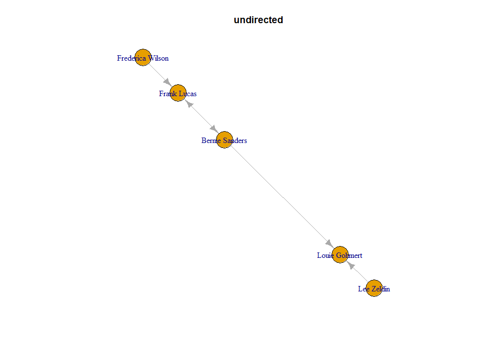

```r
names<-get_diameter(g,directed=FALSE)
vertex_names <- list()

for (i in 1:length(names)) {
  vertex_names[[i]] <- names[[i]]$name
}

vertex_indices <- V(g)$name %in% vertex_names

subgraph <- induced_subgraph(g, vertex_indices)

plot(subgraph,main="undirected")
```

We see that the diameter is larger for the strong case. We could have expected this due to the fact that the longest geodesic distance is larger for this case than for the weak case.

## 2.6 Adjacency matrix: a naïve measure of density

In this last part, we wish to show the graph in a matrix form. For this purpose, we use the adjacency matrix, where intead of describing the graph with the edges, the adjacency matrix describes the relationships with ones and zeros.

```r
A = as_adjacency_matrix(g)
print(A)
```

```
## 475 x 475 sparse Matrix of class "dgCMatrix"
```

```
##   [[ suppressing 33 column names 'Tammy Baldwin', 'John Barrasso', 'Michael Bennet' ... ]]
```

[output not shown]

[output cut: 900 more lines]

[output not shown]

Our matrix is so big that is hard to interpret it. For this reason, we will be using a heatmap, so that we can have a better glimpse of what is happening with the edges.

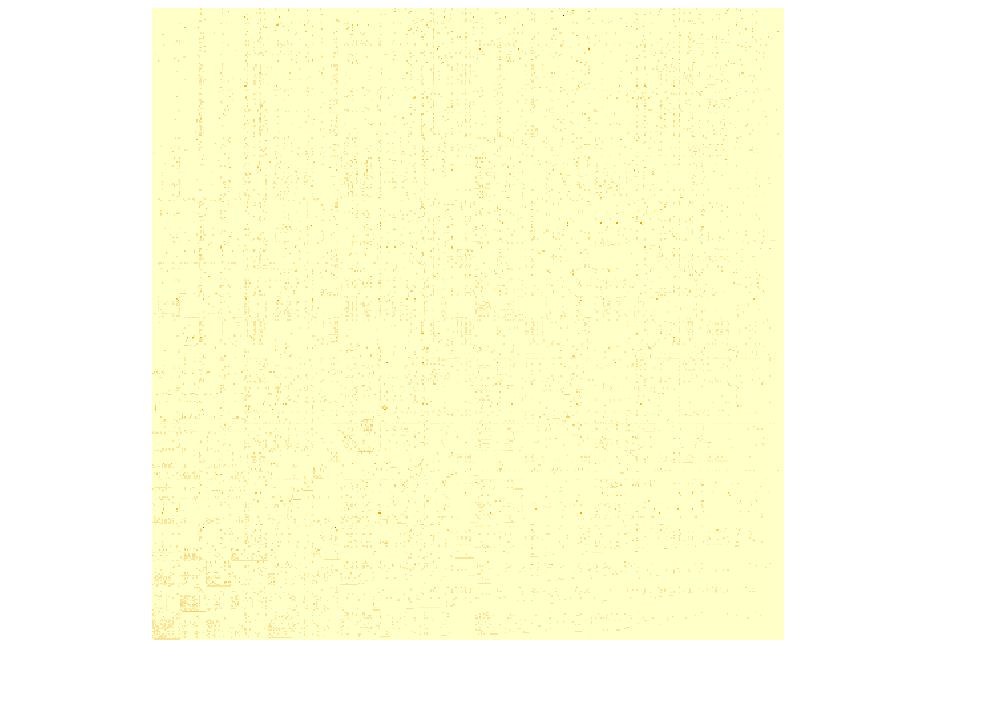

```r
heatmap(as.matrix(A), Rowv=NA, Colv=NA, labCol=NA, labRow=NA)
```

This matrix doesn’t need to be symmetric, due to the fact that the network is directed. It looks like the number of edges is low, relative to all possible interactions between all vertices, suggesting a sparse graph.

A weighted adjacency matrix could also be computed. However, it does not make much sense since the non-weighted adjacency matrix suggests a sparse graph, and in the heatmap we hardly see the darkest points. Thus, the results from the heatmap would be even harder to interpret.

# 3 Assignment 3

## 3.1 Simple graph layouts

We can start by plotting the network at hand using some standard graph layouts. As our network is not small, these are not expected to work particularly well. Nonetheless, they might still be able to shed some light or bring some insights on the less-obvious features of the infleucne relations between US Congresspeople.

The circle and star layouts are a good starting point. Instead of using the default star layout, which places the first vertex in the middle, it has been modified to place the vertex of highest degree in the center in an attempt to achieve a clearer visualization.

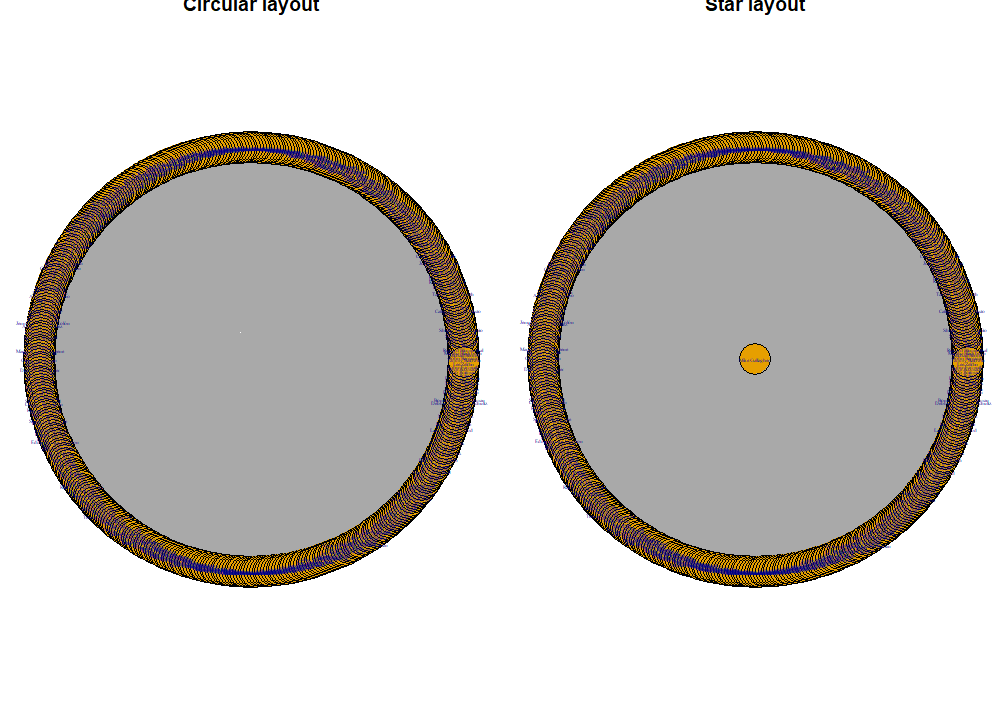

```r
par(mar=c(0,0,0,0)+.3, mfrow=c(1,2))
plot(g, layout=layout_in_circle,
     vertex.label.cex=0.3,
     main="Circular layout")
plot(g, layout=layout_as_star(g,center=V(g)[which(degree(g)==max(degree(g)))]),
     vertex.label.cex=0.3,
     main="Star layout")
```

As was already warned, these layouts do not work particularly well for this network due to its high order and size. Furthermore, they seem to indicate that this is an extremely dense network, which as we saw in previous week through the study of the adjacency matrix is not quite the case.

Next, the standard tree layout can be considered.

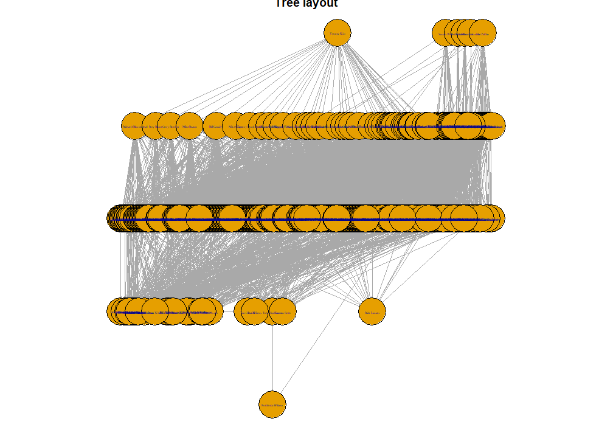

```r
par(mar=c(0,0,0,0)+.3)
plot(g, layout=layout_as_tree,
     vertex.label.cex=0.3,
     edge.arrow.size=0.1,
     main="Tree layout")
```

Once again, we find a layout that is overwhelmed by the sheer amount of vertices and interactions between them. Unlike in previous layotus however, the tree layout does provide insight into the network’s communities, with perhaps four main communities connected by certain vertices, and even some rather isolated members of US Congress.

Finally, we can give the grid and sphere layouts a try.

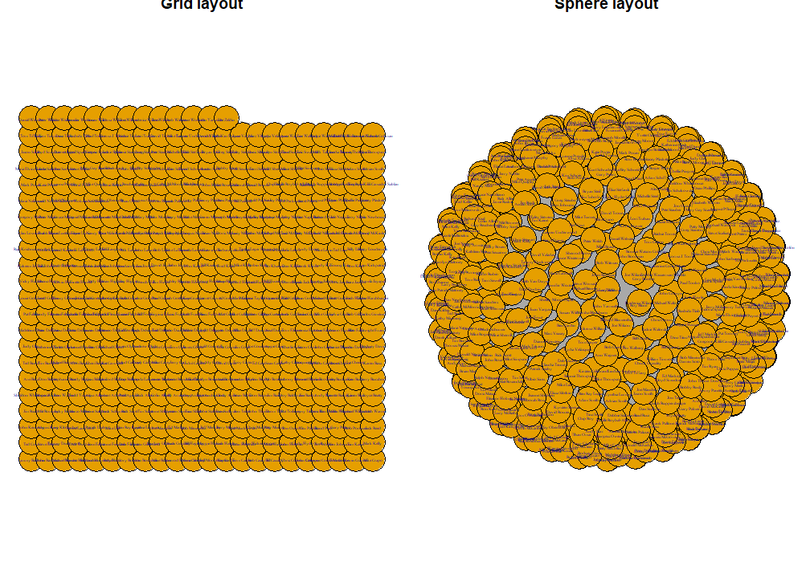

```r
par(mar=c(0,0,0,0)+.3, mfrow=c(1,2))
plot(g, layout=layout_on_grid,
     vertex.label.cex=0.3,
     main="Grid layout")
plot(g, layout=layout_on_sphere,
     vertex.label.cex=0.3,
     main="Sphere layout")
```

These layouts do not seem to be good options for the visualization of the network either.

All in all, simple graph layouts seem to lack the sophistication required to represent a network of this size in a clear manner, although the tree layout does allow for the gathering of some possible insights into its structure.

## 3.2 Graph layouts based on energy functions

Some more sophisticated layouts are those obtained my maximizing energy functions. The optimization process that leads to these visualization attempts to distribute vertices away from each other, keep edges short and minimize edge crossings, all while trying to keep vertices from coming too close to edges.

Each vertex’s position is calculated and stored with a matrix that can be fed later to the `plot.igraph` function. The matrices for all the different energy functions that will be studied in this report are calculated below:

```r
dh = layout_with_dh(g)
fr = layout_with_fr(g)
gem = layout_with_gem(g)
graphopt = layout_with_graphopt(g)
kk = layout_with_kk(g)
```

We start by studying the Davidson-Harel layout, based on a simulated annealing algorithm.

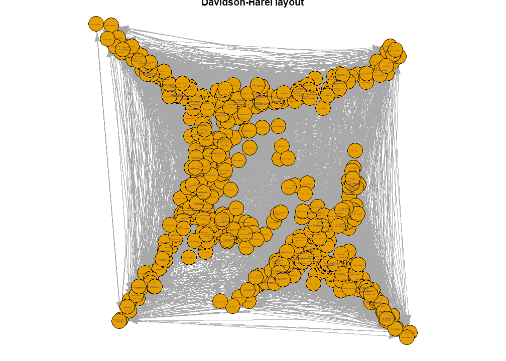

```r
par(mar=c(0,0,0,0)+.3)
plot(g, layout=dh,
     vertex.label.cex=0.2, vertex.size=10,
     main="Davidson-Harel layout")
```

The Davidson-Harel layout seems to indicate the existence of two main communities, although not very well separated due to some vertices acting as links between them.

The next energy function studied is that of the Fruchterman-Reingold layout, a force-directed algorithm which uses an analogy of physical springs as edges that attract connected vertices toward each other, while keeping a repulsive force attempting to separate all vertices from one another.

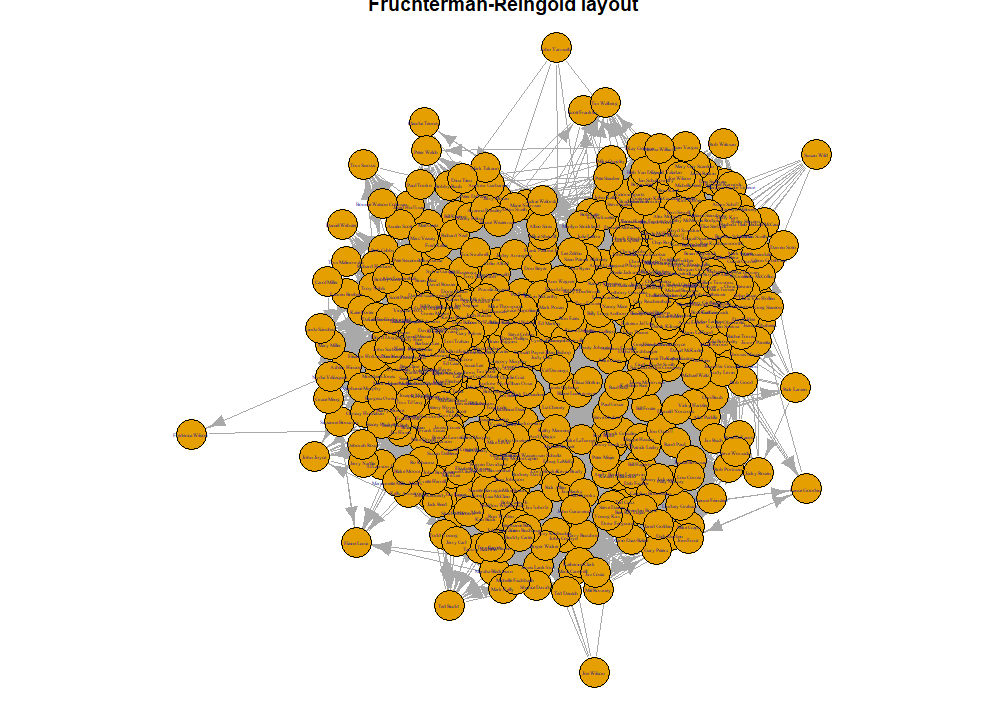

```r
par(mar=c(0,0,0,0)+.3)
plot(g, layout=fr,
     vertex.label.cex=0.3, vertex.size=10,
     main="Fruchterman-Reingold layout")
```

This algorithm does not a yield a very clear visualization of the network.

The next algorithm to be studied is the GEM force-directed layout, which just like before uses an analogy of attractice and repulsive forces between vertices taking into account the edges.

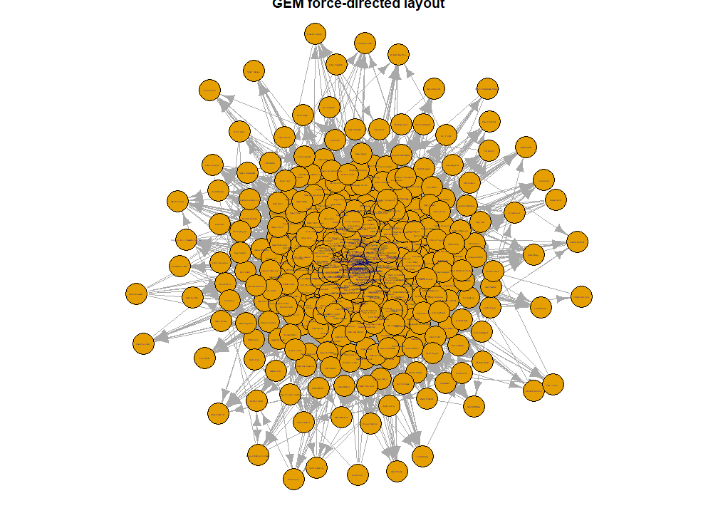

```r
par(mar=c(0,0,0,0)+.3)
plot(g, layout=gem,
     vertex.label.cex=0.2, vertex.size=10,
     main="GEM force-directed layout")
```

Although once again not a very clear plot, this layout allows to perhaps identify those vertices that are either mostly influencers or mostly influenced, since they seems to sit in the outer regions of the network. Notice however that said vertices seems to have smaller degrees.

To end, another force directed algorithm is used, the Graphopt layout algorithm, as well as a different approach, the Kamada-Kawai layout algorithm.

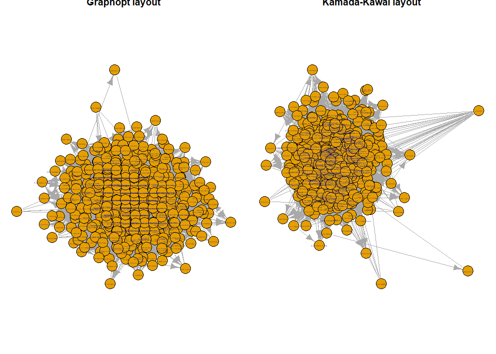

```r
par(mar=c(0,0,0,0)+.3, mfrow=c(1,2))
plot(g, layout=graphopt,
     vertex.label.cex=0.2, vertex.size=10,
     main="Graphopt layout")
plot(g, layout=kk,
     vertex.label.cex=0.2, vertex.size=10,
     main="Kamada-Kawai layout")
```

## 3.3 Graph layout based on Multidimensional Scaling

The next and final layout that will be studied is the one based on the statistical technique known as Multidimensional Scaling. The idea behind this is the projection of points from a higher dimensional space onto a plane, while trying to keep the distance between points as faithfully as possible.

```r
mds = layout_with_mds(g)
```

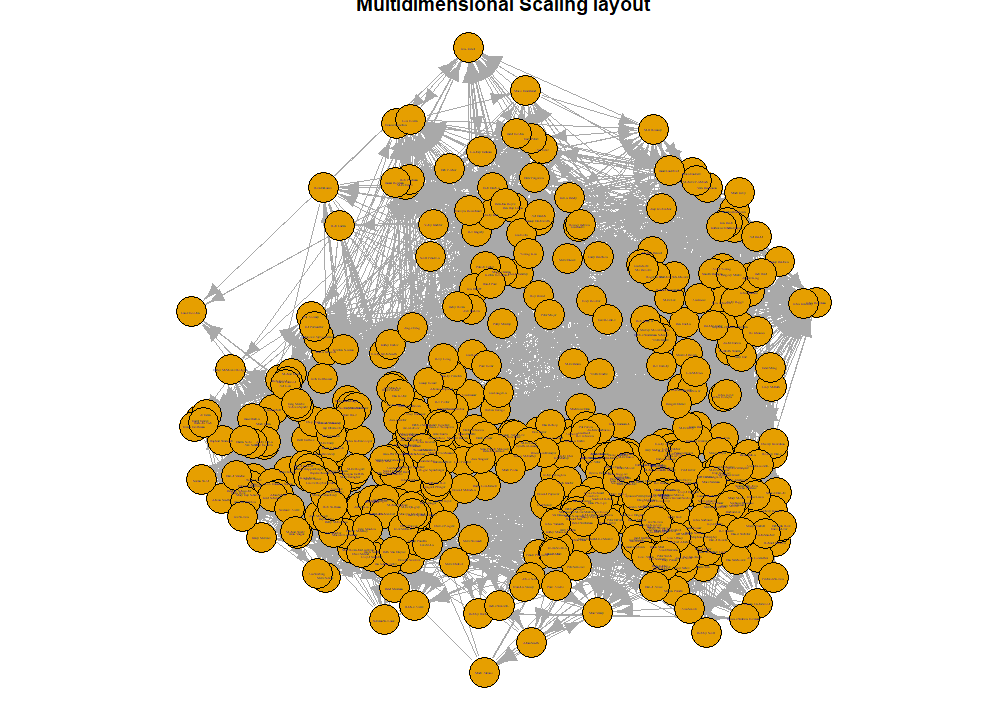

```r
par(mar=c(0,0,0,0)+.3)
plot(g, layout=mds,
     vertex.label.cex=0.2, vertex.size=10,
     main="Multidimensional Scaling layout")
```

In this layout we observe what could seem like two main communities which are not fully separated, as well as perhaps a third or even forth one. Furthermore, we also observe some vertices that interact less with the rest.

## 3.4 Best graph layout

Since it has been able to represent together features that were observed separately in other layouts, Multidimensional Scaling (MDS) has been considered the best layout. Nonetheless, the standard MDS layout is not clear enough, as so we will now attempt to obtain a clearer visualization of our network by modifying features of the vertices and edges such as size, width or color, guided by the attributes of the network.

We can start by adding colors to the plot. The color of the vertices will represent the Congressperson’s political affiliation.

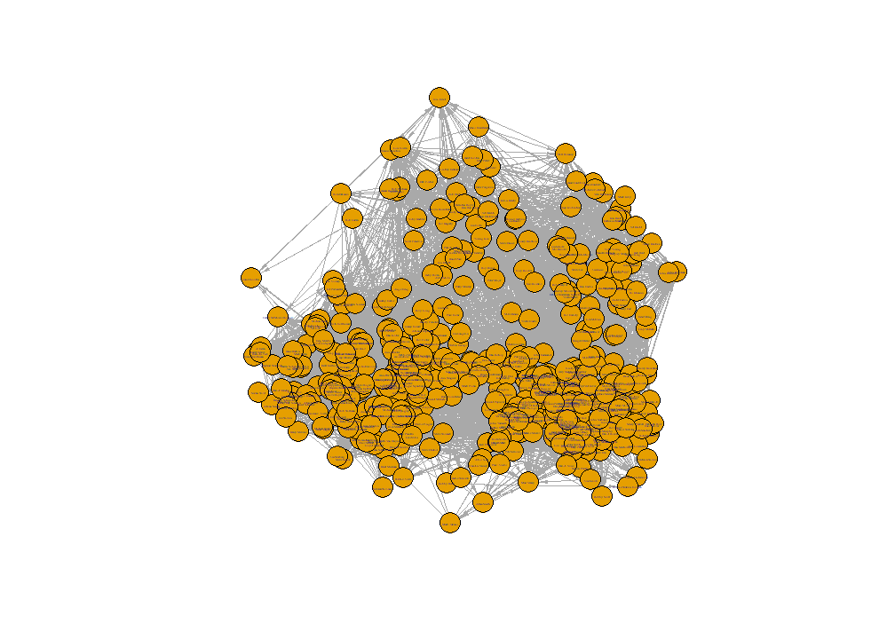

```r
plot(g, layout=mds,
     vertex.label.cex=0.2, vertex.size=10,
     edge.width=0.2,
     edge.arrow.size=0.5, edge.arrow.width=0.5)
```

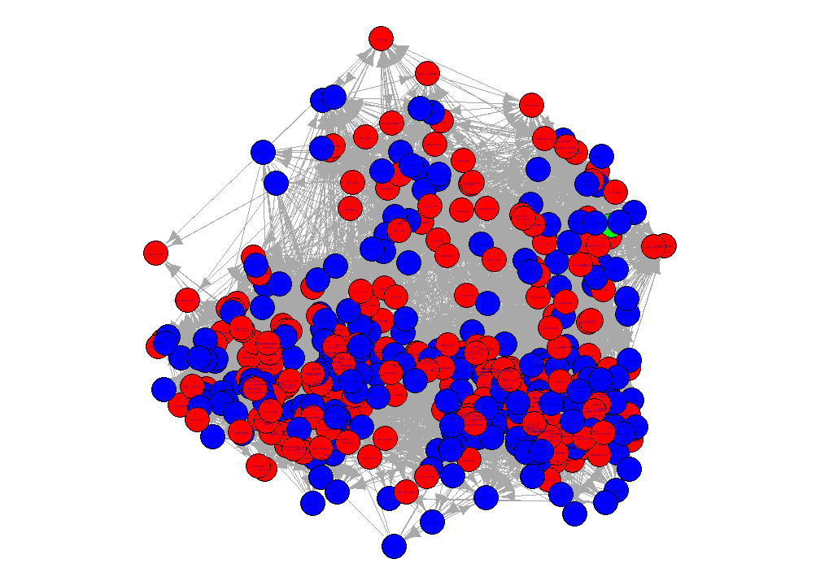

```r
par(mar=c(0,0,0,0)+.3)

V(g)[affiliation=="Republican"]$color = "red"
V(g)[affiliation=="Democratic"]$color = "blue"
V(g)[affiliation=="Independent"]$color = "green"

plot(g, layout=mds,
     vertex.label.cex=0.2, vertex.size=10)
```

Next, the size of the vertices can be modified according to their degree, so that more important Congresspeople are represented by bigger vertices.

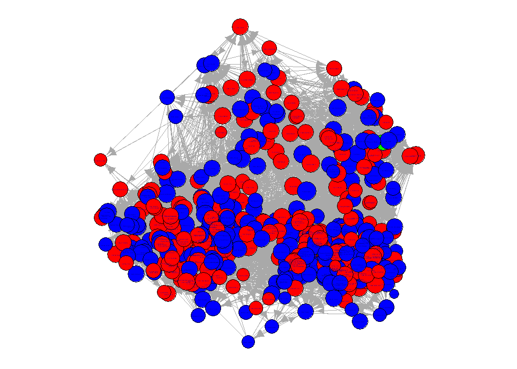

```r
par(mar=c(0,0,0,0)+.3)
V(g)$size = 1.5*log(degree(g))+5

plot(g, layout=mds,
     vertex.label.cex=0.2)
```

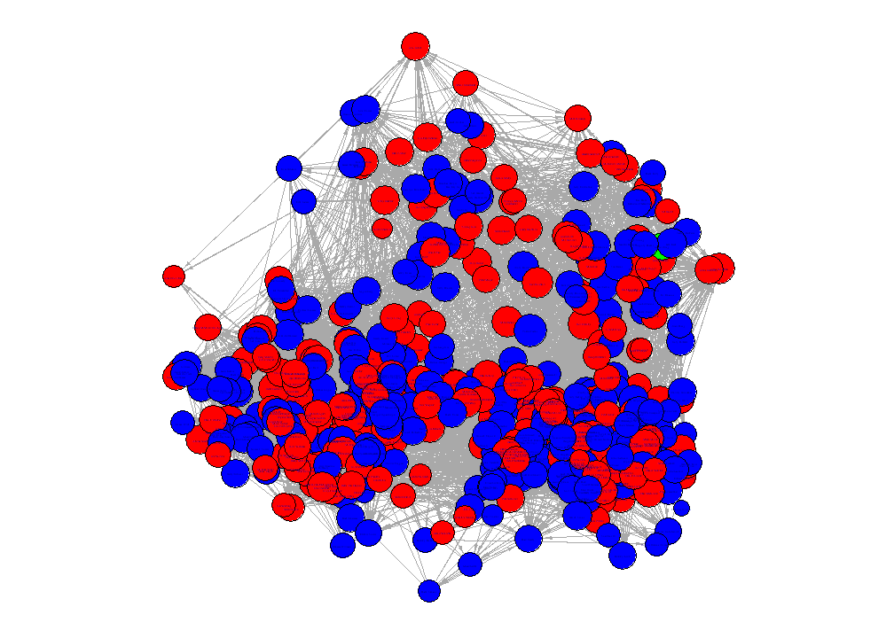

```r
par(mar=c(0,0,0,0)+.3)
#(g)$width = (E(g)$weight - min(E(g)$weight)) / (max(E(g)$weight) - min(E(g)$weight))

plot(g, layout=mds,
     vertex.label.cex=0.2,
     edge.arrow.size=0.5, edge.arrow.width=0.5)
```

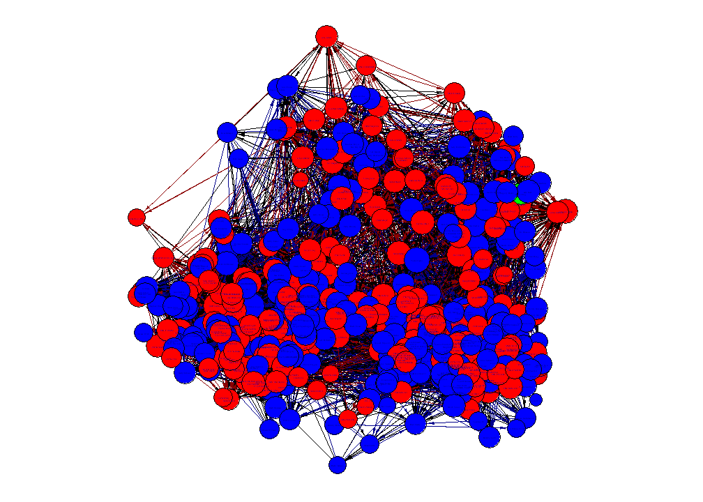

```r
par(mar=c(0,0,0,0)+.3)

reps = V(g)[affiliation=="Republican"]
dems = V(g)[affiliation=="Democratic"]
inds = V(g)[affiliation=="Independent"]

E(g)$color = "black"
E(g)[reps %--% reps]$color = "darkred"
E(g)[dems %--% dems]$color = "darkblue"
E(g)[inds %--% inds]$color = "darkgreen"

plot(g, layout=mds,
     vertex.label.cex=0.2,
     edge.arrow.size=0.5, edge.arrow.width=0.5)
```

However, even after attempting several combinations of colors, this last step does not seem to lead a clearer visualization.

```r
g = delete_edge_attr(g,"color")
```

The best visualization of the network considered is the following one:

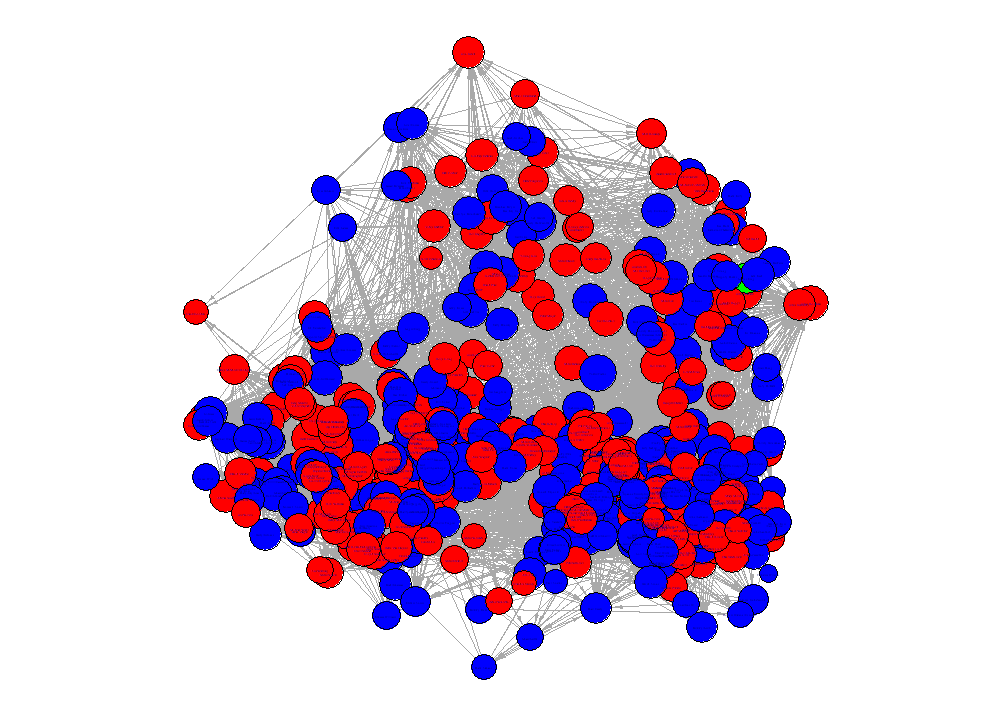

```r
par(mar=c(0,0,0,0)+.3)

plot(g, layout=mds,
     vertex.label.cex=0.2,
     edge.arrow.size=0.5, edge.arrow.width=0.5)
```

## 3.5 Power law distribution

### 3.5.1 Degrees and their distributions in the non-weighted graph

We compute the order of the graph and the degree sequence of the network and the average degree of the network.

```r
gorder(g)
```

```
## [1] 475
```

```r
head(degree(g),n=30)
```

```
##          Tammy Baldwin          John Barrasso         Michael Bennet
##                     46                     65                     62
##       Marsha Blackburn     Richard Blumenthal              Roy Blunt
##                     45                     81                     61
##            Cory Booker           John Boozman             Mike Braun
##                     82                     82                     79
##          Sherrod Brown         Maria Cantwell   Shelley Moore Capito
##                     83                     69                     50
##             Ben Cardin             Tom Carper          Bob Casey Jr.
##                     62                     56                     44
##           Bill Cassidy            Chris Coons            John Cornyn
##                    119                     75                     19
## Catherine Cortez Masto             Tom Cotton           Kevin Cramer
##                     81                     71                    115
##             Mike Crapo               Ted Cruz           Steve Daines
##                     41                     51                     57
##        Tammy Duckworth            Dick Durbin             Joni Ernst
##                    123                     42                     42
##       Dianne Feinstein            Deb Fischer     Kirsten Gillibrand
##                     32                     42                     39
```

```r
mean(degree(g))
```

```
## [1] 55.95368
```

```r
table(degree(g))
```

```
##
##   2   5   7   8   9  10  11  12  13  14  15  16  17  18  19  20  21  22  23  24
##   1   2   1   1   1   2   4   2   4   2   2   3   1   5   2   3   5   4   8   4
##  25  26  27  28  29  30  31  32  33  34  35  36  37  38  39  40  41  42  43  44
##  10   5   4   8  10   5   7   5  14   8  10   9   9  10  11   3   6  10   5   4
##  45  46  47  48  49  50  51  52  53  54  55  56  57  58  59  60  61  62  63  64
##   5   6  10   7  10   5   8   6   4   6   6   5   4   4   4   7   6  10   3   6
##  65  66  67  68  69  70  71  72  73  74  75  76  77  78  79  80  81  82  83  84
##  12   4   5   2   2   5   2   3   3   2   5   4   1   1   1   4   2   2   6   3
##  85  86  88  89  90  91  92  93  94  95  96  97  98  99 100 103 106 108 109 110
##   1   1   3   1   1   1   2   2   6   2   5   3   4   2   2   2   2   1   1   1
## 113 115 118 119 120 121 122 123 124 125 126 128 137 138 139 140 142 147 148 152
##   1   1   1   1   1   1   2   1   1   1   1   1   1   1   1   1   1   1   3   1
## 157 163 182 187 190 261 284
##   1   2   1   1   1   1   1
```

We take a look at the degree distribution and we plot it to better visualize it.

```r
head(degree_distribution(g),n=20)
```

```
##  [1] 0.000000000 0.000000000 0.002105263 0.000000000 0.000000000 0.004210526
##  [7] 0.000000000 0.002105263 0.002105263 0.002105263 0.004210526 0.008421053
## [13] 0.004210526 0.008421053 0.004210526 0.004210526 0.006315789 0.002105263
## [19] 0.010526316 0.004210526
```

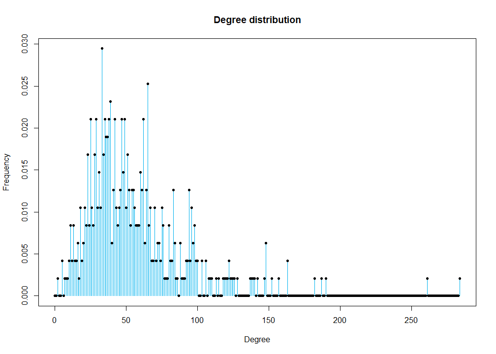

```r
color_1 <- "deepskyblue2"
par(mar=c(5,4,4,2)+0.1)
plot(0:max(degree(g)),degree_distribution(g),col=color_1,
     main="Degree distribution",
     xlab="Degree",ylab="Frequency",type="h",lwd=1.5)
points(0:max(degree(g)),degree_distribution(g),pch=20)
```

We can see that it is right-skewed. The average we computed 55.9536842 is very low compared to some values that are as high as 250 and more.

We check that the network is sparse. For that we obtain the ratio between the size of the network and the maximum number of edges that might exist. Given $V$, the number of vertices, the maximum number of edges is
$$\frac{V(V-1)}{2}$$

```r
ecount(g)
```

```
## [1] 13289
```

```r
vcount(g)*(vcount(g)-1)/2
```

```
## [1] 112575
```

```r
ecount(g)/(vcount(g)*(vcount(g)-1)/2)
```

```
## [1] 0.1180457
```

The ratio is given by $0.118$, meaning only that $11.8%$ of the potential edges already exist.